# Experiential Learning & Gender Stereotypes in Science Education

Evidence from a Field Intervention

UW Foster School of Business | February 7, 2025

**Shrihari (Hari) Sridhar**

Joe B Foster ’56 Chair in Business Leadership  
Senior Associate Dean

Mays Business School, Texas A&M University

**Joint work with:** Muzeeb Shaik, Huanhuan Shi, Adithya Pattabhiramaiah

## Research Evolution

Marketing Resource Allocation

• Media Platforms

➔

Financial Impact of Marketing Strategy

• Digital Platforms  
• B2B  
• Healthcare  
• Education

➔

Financial and Societal Impact of Marketing Strategy

• Digital Platforms  
• B2B  
• Healthcare  
• Education

## SDIAS and School Disciplinary Problems

$1 million increase in school district internet access spending

→

7% increase in the number of lower-severity disciplinary problems in a school

→

$5,529~$11,451 increase in cost to a school

→

$38,700~$80,160 increase in cost to a school district*

**Implication**

Technology investments in schools can have unintended behavioral consequences that need to be considered

**Reference**

Chen et al. *Journal of Marketing Research* (2021)

## Personalized Cancer Screening Saves Money and Lives

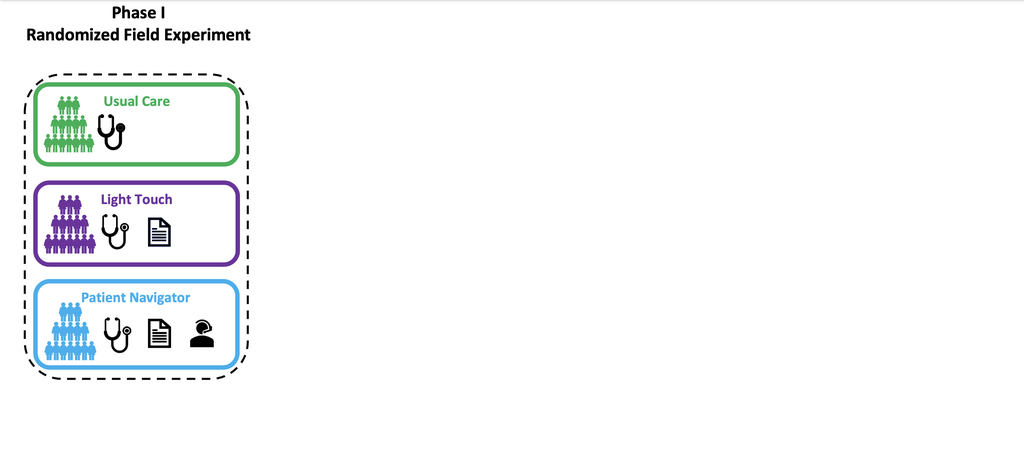

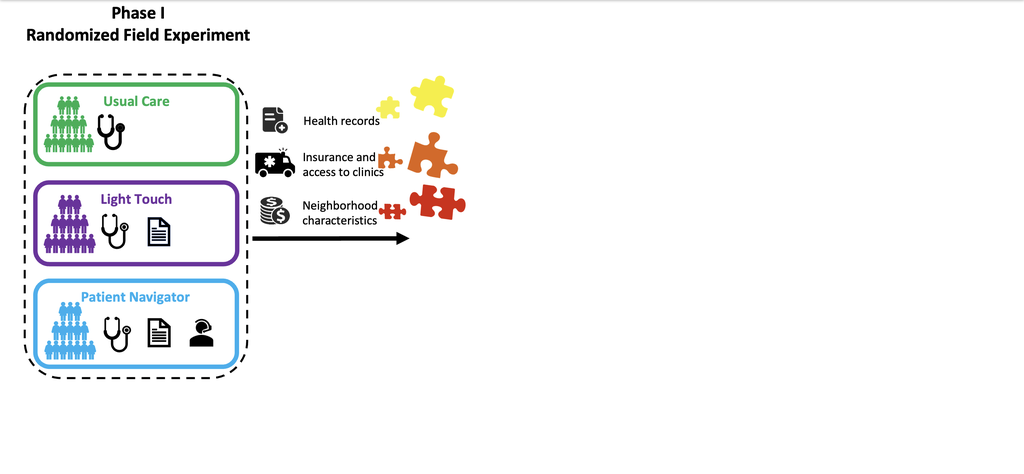

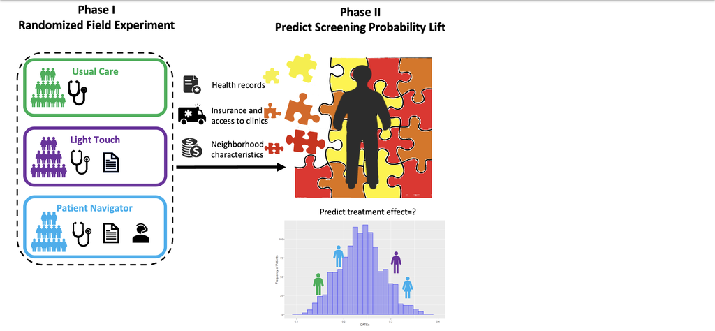

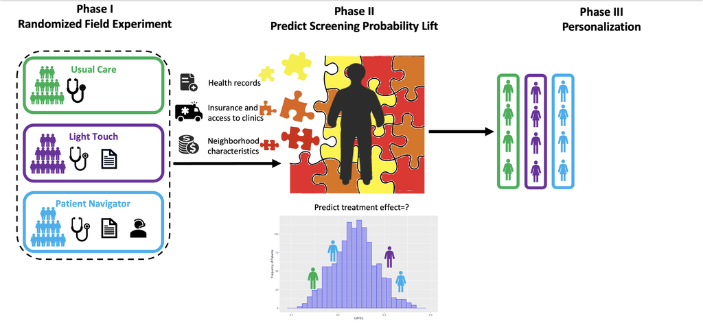

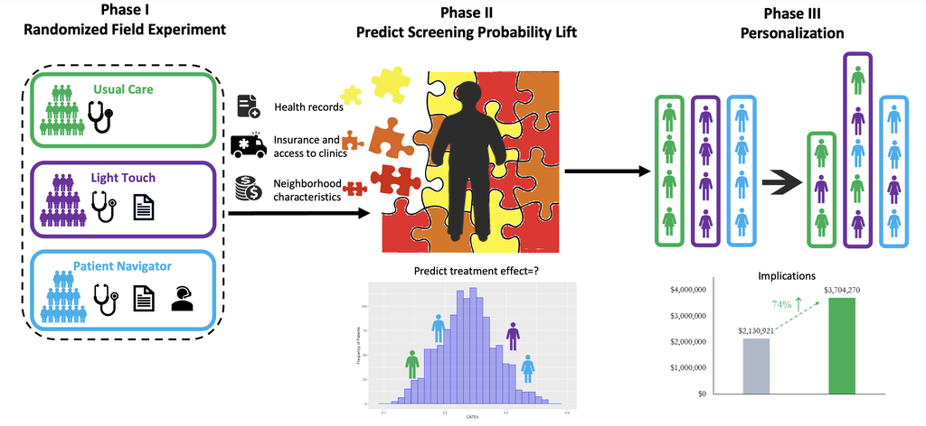

**Reference**

Chen et al. *Journal of Marketing* (2020)

## How Fatal School Shootings Impact a Community’s Consumption

### Research Question

How do fatal school shootings affect grocery and public consumption in affected communities?

#### Key Findings

- **-2.09%** decrease in grocery spending after incidents
- **-1.17%** fewer shopping days
- **-1.25%** fewer unique stores visited
- Effects stronger in **liberal-leaning counties**

#### Mechanism

- **Anxiety** drives reduced consumption
- Effect specific to **public consumption** contexts
- Moderated by **political ideology**

**Implications**

Understanding community-level behavioral responses to trauma is critical for local stakeholders and marketers

**Reference**

Shaik et al. *Journal of Marketing Research* (2025)

# Experiential Learning & Gender Stereotypes in Science Education

## The Gender Gap in STEM: A Global Challenge

### Global Picture

- Education: **4–5% of global GDP** (~USD 4.4–5.6 trillion annually)
- Women: only **35%** of STEM graduates worldwide
- In the US: **38.8%** of science bachelor’s degrees
- Only **26%** of the US STEM workforce

### India: Our Study Context

- Women: **43%** of total undergraduate enrollment
- But only **29%** in STEM disciplines
- Fewer than **18%** of scientists/engineers in labor force
- **Opportunity:** Gender parity → **10–12 million** more STEM workers

**Today’s Talk**

What if we could address gender stereotypes **indirectly**, not through persuasion campaigns, but by **redesigning the learning experience itself**?

## Three Categories of Prior Interventions

### 1. Push Campaigns

- Awareness campaigns
- Mass communication
- Public service announcements
- Media messaging

**Goal:** Persuade individuals to reconsider stereotypes

*(Paluck et al. 2021; Hermann et al. 2022)*

### 2. Girls-Only Programs

- After-school STEM activities
- Mentoring programs
- Interactions with STEM professionals
- Separation as confidence-building

**Goal:** Close information gaps, build exposure

*(Dubetz & Wilson 2013; Levine et al. 2015)*

### 3. Gender-Congruent Environments

- Female role models
- Feminine classroom décor
- Identity-affirming cues

**Goal:** Counteract masculine coding of science

*(Master et al. 2016; Breda et al. 2023)*

**The Common Limitation**

All three approaches **explicitly position gender as the focal problem** and attempt to address it through direct persuasion or identity-targeted messaging. **Evidence on effectiveness is mixed:** meta-analyses show modest effects that often fade over time, and some interventions can backfire by reinforcing the very stereotypes they aim to reduce.

## Disadvantages of Direct Approaches

### These interventions risk **reactance**:

**Push Campaigns**

- May be dismissed as heavy-handed
- Risk appearing tokenizing
- Limited lasting impact on beliefs

**Girls-Only Programs**

- Can **reinforce** the very group boundaries they seek to dismantle
- Signal that girls require specialized support
- Create parallel tracks rather than inclusive culture

**Gender-Congruent Cues**

- Signal science requires **special adaptation** for women
- Rather than science being a shared, gender-neutral domain

**An Alternative Possibility**

What if there’s a way to preserve participation across genders and generate positive outcomes? An approach that engages **both boys and girls** together, where boys—who often hold stronger gender-stereotypical beliefs—can update their perceptions through shared experience?

## A Different Approach: Indirect Change

**The Core Insight**

Rather than **targeting gender perceptions directly**, what if we could produce gender-inclusive outcomes as a **collateral benefit** of redesigning the learning experience itself?

### Research Questions

**Primary:** Can experiential science learning, designed for *pedagogy*, simultaneously improve science knowledge **and** reduce gender stereotypes?

**Secondary:**

- Does the intervention affect boys and girls differently?
- Do effects extend to broader attitudes about gender and competence?

## Our Approach: A Pedagogy-First Service Intervention

**Our approach is a pedagogy-first service intervention.**

**The program was NOT designed to address gender stereotypes.**

Its primary objective is **pedagogical**: supplement chalk-and-talk instruction with experiential, hands-on science learning.

But its design includes features that may **inadvertently** reduce gendered perceptions of science.

**Study Design:**

- **N = 5,216** students
- **196** rural public schools
- Bodoland, Assam, India
- One academic year
- Difference-in-differences

**Preview**

**+14 pp** science knowledge gain | **~20%** reduction in gender stereotypes

## Roadmap for Today’s Talk

- **Theoretical Framework** - Shared experiential consumption & cross-gender contact
- **Institutional Context** - Science education in rural India
- **The Intervention** - Mobile Science Labs program design
- **Research Design** - Sample, measures, and analytical approach
- **Results** - Main effects and heterogeneity analyses
- **Discussion** - Contributions and implications

# Theoretical Framework

## Experiential Learning Can Change Perceptions and Outcomes

### Core Insight

**Experiential learning interventions can change both knowledge and social perceptions.**

When science learning is structured as **shared experiential consumption**, cross-gender collaboration triggers **belief updating**:

- Students observe counter-stereotypical competence firsthand
- Direct evidence challenges prior gender-science associations
- Shared experience creates common identity around science

*(Ramanathan & McGill 2007; Allport 1954; Pettigrew & Tropp 2006)*

### Our Approach vs. Direct Interventions

| Direct Approaches | Our Approach |
| --- | --- |
| Persuasion/messaging | **Direct experience** |
| Separate girls from boys | **Shared domain** |
| Role models/cues | Students as **evidence** |
| Inclusion as external layer | **Embed inclusion** |

**Key Difference**

Students encounter counter-stereotypical participation **organically** through mixed-gender collaboration under conditions of equal status, common goals, and institutional support

## The Delivery Mechanism: Experiential Learning

**Kolb’s Experiential Learning Cycle (1984)**

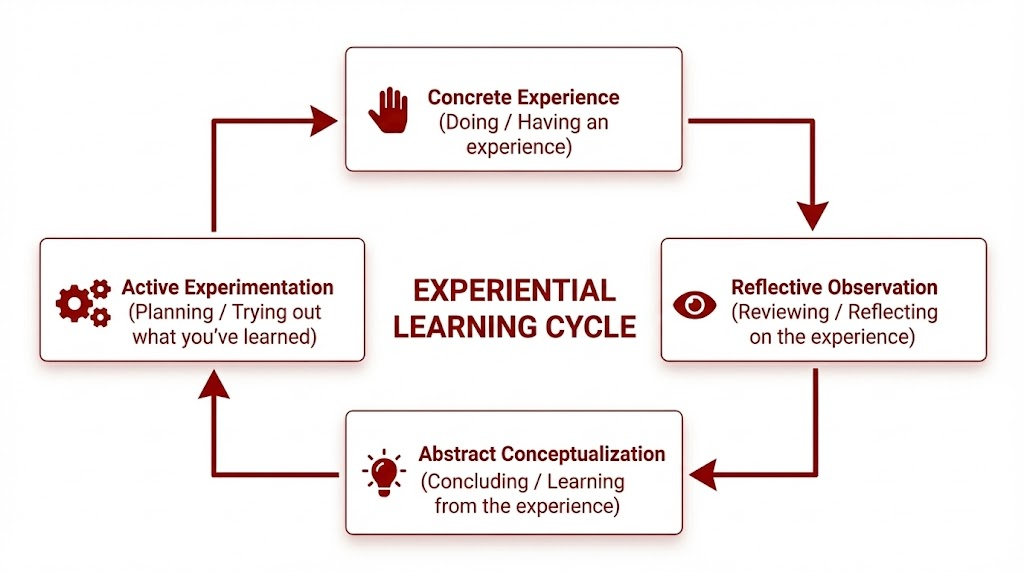

### Theory of Change

**Input:** Experiential learning designed for *pedagogy*, not gender

**Mechanism:** Shared experiential consumption triggers **belief updating** through:

- **Joint problem-solving** during experiments
- **Collaborative sense-making** of results
- **Equal participation** in learning tasks

**Dual Outcomes:** Learning gains (primary goal) AND stereotype reduction (collateral benefit)

## What We Expect to Find

### Primary Outcome: Science Knowledge

**The Pedagogical Goal**

Experiential learning will **improve science knowledge** through:

- Concrete experience with concepts
- Reflective observation and discussion
- Abstract conceptualization
- Active experimentation and application

### Added Benefit: Reduced Stereotypes

**The Indirect Effect**

Shared experiential consumption may **reduce gender-stereotype attitudes** through:

- Cross-gender contact under optimal conditions
- Organic exposure to counterexamples
- Weakening of group boundaries
- Students experiencing science as “for us”

# Institutional Context

## Science Education in Indian Public Schools

### The System

- **70%** of students attend government schools
- Critical for educational equity and access
- Serves primarily low-income communities
- **Why Indian public schools?** Large population with persistent gender gaps in STEM; traditional pedagogical methods provide clear contrast for intervention; findings can inform policy at scale

### Infrastructure Challenges

- **>50%** of Grades 9-10 students learn science **without proper labs**
- Remote areas lack dedicated laboratory facilities
- Cannot engage in hands-on experiments
- High student-teacher ratios: **20:1 to 27:1**

### Pedagogical Approach

- Emphasis on **memorizing facts** from textbooks
- Content-heavy, examination-focused curriculum
- Only **14%** of classrooms use non-textbook materials
- **Rote learning dominates** instruction

### The Result

- Passive, one-way information transfer
- Minimal student engagement
- No inquiry-based learning
- Limited critical thinking development

## Traditional Classroom Environment

### What You See

- **Gender-segregated seating** (boys on one side, girls on other)
- Passive, lecture-based instruction
- Teacher-centered pedagogy

### The Problem

- Reinforces gender boundaries
- No cross-gender collaboration

**The Gap**

Lack of hands-on, interactive learning: exactly where experiential learning could make a difference

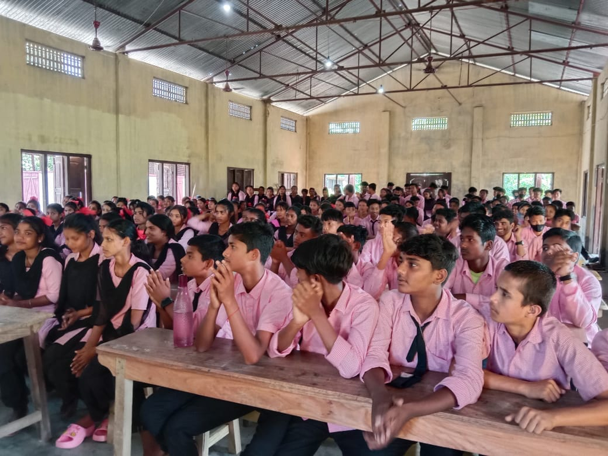

## Study Location: Bodoland, Assam

### Geographic Context

- **Autonomous territorial region** in Northeast India (Assam state)
- Established in 2003; Bodo population and other ethnic communities
- Complex socio-political environment

### Why This Location?

- **Clean baseline** - limited prior exposure to experiential learning
- **High need** - underserved schools, resource constraints
- **Scalability insights** - if it works here, it can work anywhere

### Socioeconomic Profile

- Widespread **socioeconomic disadvantage**
- **Educational underdevelopment** compared to national averages
- Predominantly rural population

### Educational Context

- Schools operate with minimal facilities
- Students have little exposure to hands-on science
- Traditional gender norms prevalent

## Mobile Science Labs (MSL) Program

**Program Features:**

- Vehicles equipped with lab equipment
- Two instructors + one driver per MSL
- Minimum 2 sessions per day
- Reaches 1,200+ children annually per MSL
- 475,000+ students served as of 2024

**Implementation:**

- Eight 2-hour hands-on sessions per academic year
- Sessions every few weeks throughout year
- Subjects: Biology, Chemistry, Physics

[figure not shown]

Mobile Science Lab Vehicle

**Key Feature**

Mixed-gender collaborative activities

## Students Engaged in Hands-On Learning

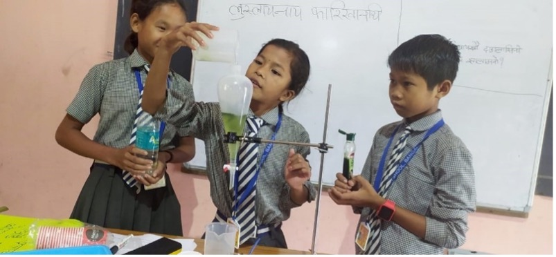

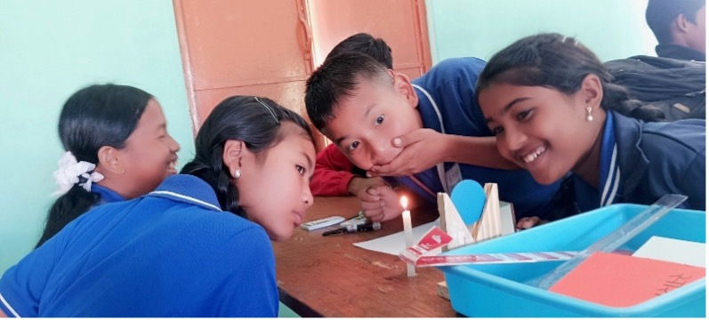

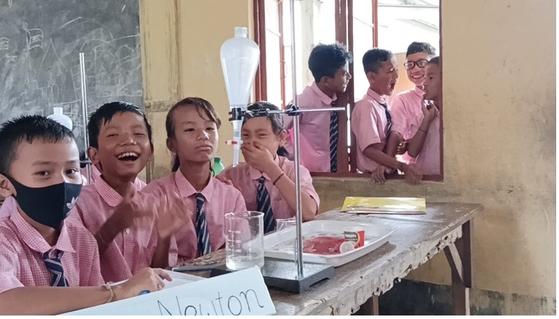

**Key Observation**

**Mixed-gender collaboration** in action: boys and girls working together on science experiments, creating conditions for belief updating through shared consumption

## How MSL Creates Contact Conditions

### Operationalizing Intergroup Contact Theory

**Theoretical Requirement** → **MSL Implementation**

**1. Equal Status**  
→ Boy-girl pairs **jointly lead** experiments in front of class  
→ Both genders perform same tasks

**2. Common Goals**  
→ Understanding scientific concepts  
→ Successfully completing experiments  
→ Shared learning objectives

**3. Cooperation**  
→ Joint problem-solving required  
→ Collaborative sense-making  
→ Peer discussion and reflection

**4. Institutional Support**  
→ Curriculum design mandates mixed-gender groups  
→ Instructor facilitation ensures equal participation  
→ School administration endorses program

**The Design**

MSL doesn’t just teach science differently. It creates a **social intervention** through the structure of collaborative learning

## MSL Curriculum Design: Kolb’s Experiential Learning Cycle

### Chemistry Example: Acids and Metal Carbonates

**1. Concrete Experience**

- Add sodium carbonate to test tube
- Add dilute hydrochloric acid
- Dip tube into limewater
- **Mixed-gender teams work together**

**2. Reflective Observation**

- What did we observe?
- Bubble formation, gas released
- Limewater changing to milky
- **Students share observations**

**3. Abstract Conceptualization**

- Released gas is CO₂
- CO₂ + limewater → calcium carbonate
- **Generalization:** Acids + carbonates → CO₂

**4. Active Experimentation**

- Make their own limewater
- Blow into it through straw
- Observe milky color change
- **Connect:** Exhaled air contains CO₂

### Session Structure

**Each session includes:**

- **4-5 activities** covering all stages
- **Mixed-gender teams** for every experiment
- **Whole-class observation** and discussion
- **Real-world connections**

**The Cycle**

Students experience → reflect → conceptualize → apply **together** in mixed-gender groups

# Research Design

## Study Design Overview

### Sample Composition

**Total Sample:**

- **N = 5,216 students**
- **196 public schools**
- **Grades 6-9** (middle school)
- **Location:** Bodoland, Assam, India

**Treatment Group:**

- **4,608 students** (88% of sample)
- Received MSL intervention
- Eight 2-hour hands-on sessions over academic year

**Control Group:**

- **608 students** (12% of sample)
- Regular public school education
- No MSL intervention

### Research Design

**Design Type:**

- **Two-wave panel design**
- Pre-intervention (baseline) assessment
- Post-intervention (endline) assessment
- **One academic year** duration

**Analytical Approach:**

- **Difference-in-differences** estimation
- Individual fixed effects
- School fixed effects
- Clustered standard errors (school level)
- Heterogeneity/moderation analyses

## Primary Outcome Measures

### Science Knowledge Score

**Measurement:**

- 4 multiple-choice questions per assessment
- Grade-specific content aligned with curriculum

**Sample Items:**

- *“When a burning candle is covered with a glass jar, the flame goes out because…”* (Answer: oxygen is used up)
- *“A ball is thrown upward. At the highest point, what forces act on it?”* (Answer: only gravity)

**Scoring:**

- Percentage of items answered correctly (0-100%)
- Enables cross-grade comparison
- Captures applied reasoning (not rote recall)

### Gender-Stereotype Attitudes

**Measurement:**

- Single-item: *“I feel science is for boys more than girls”*
- 5-point Likert scale (1 = Strongly disagree, 5 = Strongly agree)

**Interpretation:**

- Higher scores = stronger gender stereotypes

**Rationale for Single Item:**

- Appropriate for children/adolescents; avoids cognitive overload
- Established practice (Deslauriers et al. 2019; Carlana et al. 2022)

## Secondary Outcomes

**Science-Related Attitudes:**

- Interest and enjoyment in science
- Science self-efficacy
- Long-term science orientation
- Intentions to choose science major
- 14 total constructs measured

**Gendered Perceptions (Post-intervention only):**

Two questions asking students to infer likely gender of high-performing student:

- **Science domain:** “A student performs very well in science. Is this student a boy or a girl?”
- **Language arts domain:** “A student performs very well in language arts. Is this student a boy or a girl?”

## Analytical Strategy

### Difference-in-Differences Framework

**Base specification:**

$Y_{ist} = \beta_0 + \beta_1 Treatment_s + \beta_2 Post_t + \beta_3 (Treatment_s \times Post_t) + \varepsilon_{ist}$

Where:

- $Y_{ist}$ = outcome for student $i$ in school $s$ at time $t$
- $Treatment_s$ = indicator for treatment school
- $Post_t$ = indicator for post-intervention period

### What Each Term Captures

- $\beta_1$ (Treatment): Baseline difference between treatment and control
- $\beta_2$ (Post): Time trend (change in control group)
- $\beta_3$ (Treatment × Post): Additional change in treatment group beyond the control group = **CAUSAL EFFECT**

# Results: Main Effects

## Model-Free Evidence: Science Knowledge

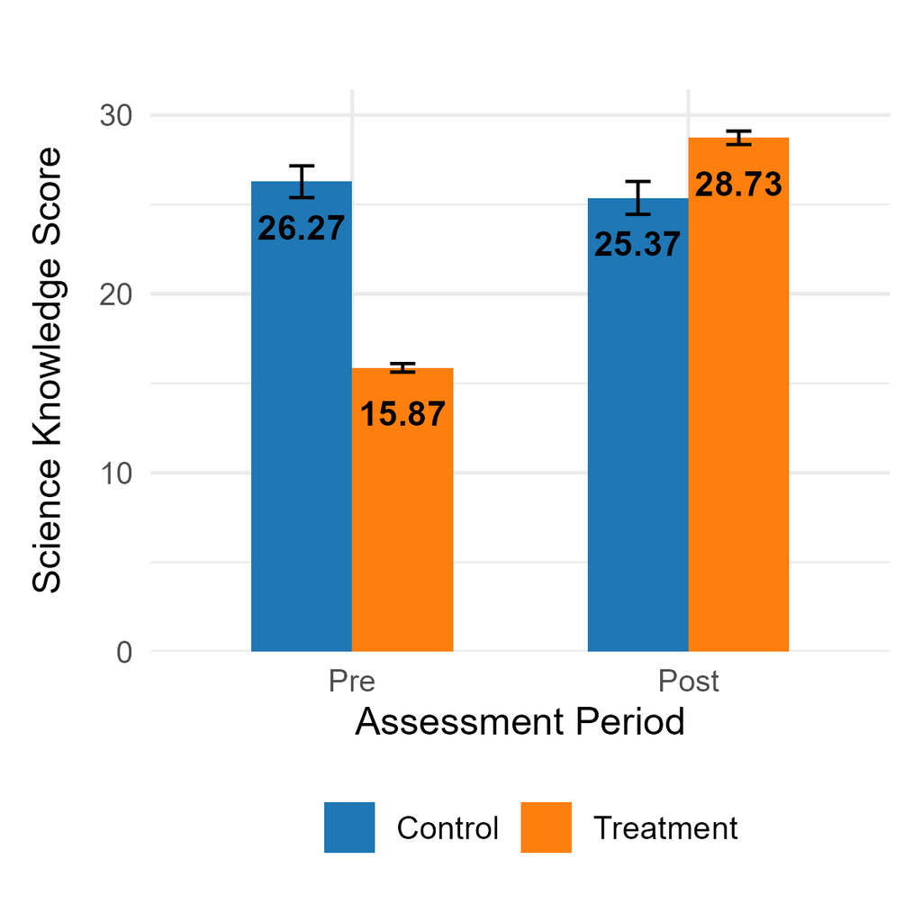

**Note**

## Model-Free Evidence: Gender Stereotypes

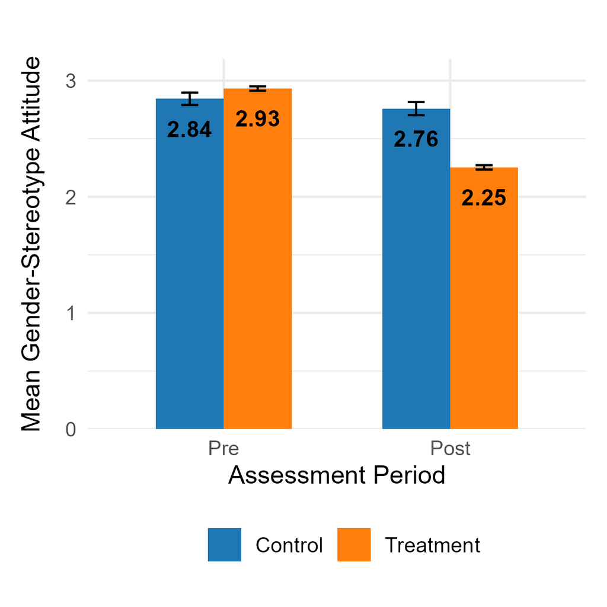

**Note**

- Control group attitudes **remained stable** over time.
- **Treatment Success:** Intervention significantly reduced “Science is for boys” beliefs.

## Regression Results

*Difference-in-Differences Estimates*

Panel A: Science Knowledge Score

|  | Model 1 | Model 2 | Model 3 | Model 4 |
| --- | --- | --- | --- | --- |
|  | No FE | School FE | School + Grade FE | School × Grade FE |
| Treatment × Post | 13.763*** | 13.763*** | 13.763*** | 13.763*** |
|  | (2.743) | (2.743) | (2.747) | (2.743) |
|  | p<.001 | p<.001 | p<.001 | p<.001 |
| N | 10,432 | 10,432 | 10,432 | 10,432 |
| R² | .076 | .255 | .317 | .398 |

Panel B: Gender-Stereotype Attitudes

|  | Model 1 | Model 2 | Model 3 | Model 4 |
| --- | --- | --- | --- | --- |
| Treatment × Post | -0.595** | -0.576** | -0.575** | -0.573** |
|  | (0.186) | (0.188) | (0.188) | (0.188) |
|  | p=.002 | p=.003 | p=.003 | p=.003 |
| N | 10,214 | 10,214 | 10,214 | 10,214 |
| R² | .061 | .205 | .207 | .236 |

*Standard errors clustered at school level*

**Science Knowledge Score**

**Effect: +13.8 pts**

88% improvement over baseline

Consistent across all specifications

✓ **Pedagogical success**

**Gender-Stereotype Attitudes**

**Effect: -0.58 pts**

~20% reduction from baseline

Robust to all controls

✓ **Social transformation**

## What Does This Mean at Scale?

### The Logic

1. Our intervention reduces gender stereotypes by **~20%**
2. Meta-analytic evidence shows brand identification elasticity of **0.439** (Khamitov, Wang, and Thomson 2019)
3. Combined effect: **20% × 0.439 = 8.8%** greater future engagement with science

### Scaling to Assam

- **3.2 million** students enrolled in public schools
- If 8.8% show increased sustained engagement…
- **= 282,000 additional students** with stronger science orientation

**Implication**

Even modest reductions in stereotypes, when scaled across large populations, can translate into **substantial human capital gains**

## Robustness Check: CEM Matching

**Why CEM Matching?** To strengthen causal credibility, we use Coarsened Exact Matching (CEM) to address baseline differences between treatment and control groups in their **Science Knowledge**. No pre-period differences in **Gender Stereotypes**

**Pre-Match Balance:**

- Treatment: 15.87%
- Control: 26.27%
- Std. Mean Diff: -0.64

**Post-Match Balance:**

- Both: 15.87%
- Std. Mean Diff: 0.00
- Perfect balance achieved

**CEM-Weighted Results:**

- Treatment × Post: 4.62†
- (SE = 2.37, p = .053)
- Confirms robustness

✓ Results hold after controlling for baseline proficiency

# Heterogeneity Analysis

## Moderation Analysis Overview

### What we are testing

Does the intervention’s impact vary by **student gender**?

- Do boys and girls respond differently to the intervention?
- Theory predicts boys (with higher baseline bias) may show larger stereotype reductions

### Analytical Approach

**Extended DiD specification:**

$Y_{ist} = \beta_0 + \beta_1 Treatment_s + \beta_2 Post_t + \beta_3 Male_{is}$ $+ \beta_4 (Treatment_s \times Male_{is}) + \beta_5 (Post_t \times Male_{is})$ $+ \beta_6 (Treatment_s \times Post_t \times Male_{is}) + \varepsilon_{ist}$

**Coefficient of interest:** $\beta_6$ (three-way interaction)

**Additional Moderators**

School size, class size, and gender composition analyses available in appendix

## Moderation by Student Gender

### Regression Results

| Parameter | Science Knowledge Score |  | Gender-Stereotype Attitudes |  |
| --- | --- | --- | --- | --- |
|  | Coef. (S.E.) | p-value | Coef. (S.E.) | p-value |
| **Treatment × Post × Male** | 0.642 (3.096) | .836 | **-0.658 (0.213)** | **.002** |
| Treatment × Post | 13.505 (3.165) | <.001 | -0.290 (0.217) | .183 |
| Treatment × Male | 1.811 (2.235) | .417 | 0.287 (0.131) | .030 |
| Post × Male | -1.275 (2.941) | .665 | 0.524 (0.203) | .011 |
| Male | -2.324 (2.147) | .280 | -0.071 (0.120) | .558 |
| Post | -0.359 (2.964) | .904 | -0.316 (0.199) | .114 |
| **N** | 10,432 |  | 10,214 |  |
| **R²** | .379 |  | .240 |  |

*School × Grade fixed effects; Standard errors clustered at school level*

**Science Knowledge Score**

**p = .836**

NOT significant

Equal gains for boys and girls (~14 pts)

**Gender-Stereotype Attitudes**

**p = .002**

Significant

Boys: 3× larger reduction compared to girls

## Why Bigger Effects for Boys?

- **Higher baseline bias** → More room for belief updating
- **Firsthand observation** of girls’ competence during shared consumption
- **Belief updating** when direct evidence contradicts prior stereotypes
- **Inter-group contact theory** prediction confirmed

**Implication**

Boys are key agents of change in creating inclusive science cultures

# Additional Results

## Broader Science Attitudes

### Beyond Primary Outcomes

We measured **14 additional constructs** capturing:

- **Interest & Enjoyment** (3 items)
- **Self-Efficacy** (4 items)
- **Long-Term Orientation** (4 items)
- **Perceived Value** (3 items)

**Question**

Does the intervention affect the **broader constellation** of science attitudes beyond knowledge and stereotypes?

## Treatment Effects on Science Attitudes

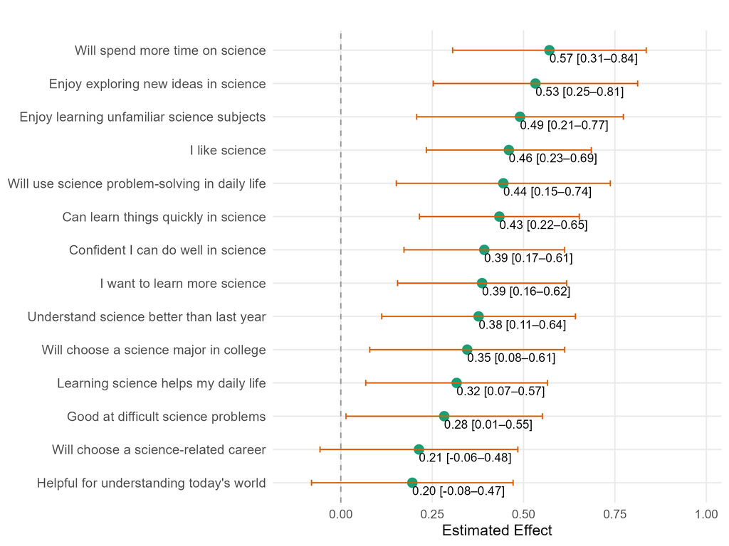

**Multifaceted Impact**

Positive Effects on 12 of 14 Outcomes

## Perceptions of Academic Excellence

**Post-intervention question:** “A student performs very well in [science/language arts]. Is this student a boy or a girl?”

**Science Excellence**

- Treatment effect: β = 0.55***
- Less likely to assume “boy”
- More “could be either” responses
- Domain-specific change

**Language Arts Excellence**

- Treatment effect: β = 0.45***
- Spillover to other domains
- Shows consistency in thinking

**Note**

# Proposed Experimental Study

## We Would Value Your Input

### Help Us Refine This Study

This experimental design is still in development. **We welcome your feedback on:**

- Are the experimental conditions well-specified?
- Are there alternative mechanisms we should test?
- What additional measures would strengthen the design?
- How might we improve ecological validity?

### Questions for Discussion

- Does the vignette approach adequately capture the experiential learning mechanism?
- What boundary conditions should we explore?
- Are there design elements that could be improved?

## Testing the Mechanism: An Experimental Approach

### The Question

Our field study shows **what** happens, but **why** does mixed-gender experiential learning reduce stereotypes?

**Key Mechanisms to Test**

1. Is **equal-status contact** necessary, or is any mixed-gender interaction sufficient?
2. Does **collaboration** matter, or would solo learning produce similar effects?
3. Which **psychol ogical mediators** drive the effect (norms, belonging, perceived competence)?

### Proposed Design: Online Experiment with Visual Vignettes

- **Participants:** U.S. respondents recruited via Prolific
- **Method:** View illustrated comic strips depicting science learning scenarios
- **Pre/Post measures:** Stereotype endorsement, science attitudes, norms

## Experimental Conditions (4 Arms)

### 1. Mixed-Gender, Equal-Status (MG-Equal)

- Boy and girl **alternate steps**
- Both explain observations
- Both make predictions
- **Equal talk time and competence cues**

### 2. Same-Gender (SG)

- Two boys (for male participants) or two girls (for female participants)
- Same script and equal-status behavior
- **Tests whether cross-gender contact is necessary**

### 3. Mixed-Gender, Unequal-Status (MG-Unequal)

- One gender leads, other observes passively
- Minimal input from passive partner
- **Tests whether equal status is necessary**

### 4. Solo Learning (Solo)

- Single student performs same activity
- Explains observations alone
- **Tests whether collaboration matters**

## Mixed-Gender, Equal-Status (MG-Equal)

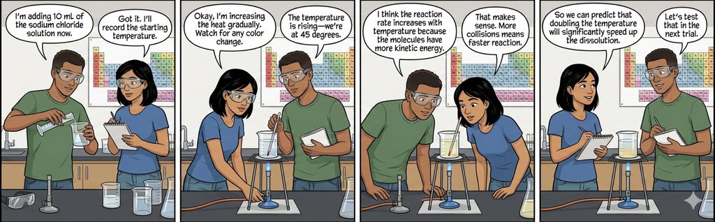

**Key Feature**

**Equal participation**: Alex (boy) and Maya (girl) alternate leading, explaining, and contributing equally throughout the experiment

## Same-Gender: Two Boys (SG-Male)

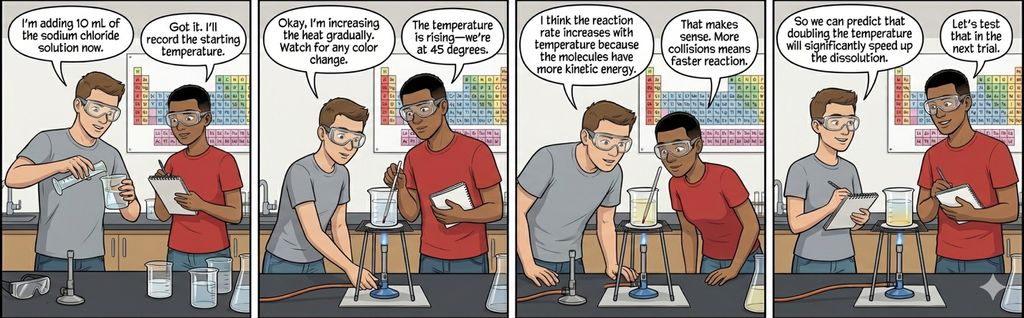

**Key Feature**

**Same-gender control**: Jake and Marcus (two boys) with equal participation. Tests whether **cross-gender contact** is necessary. *Shown to male participants.*

## Same-Gender: Two Girls (SG-Female)

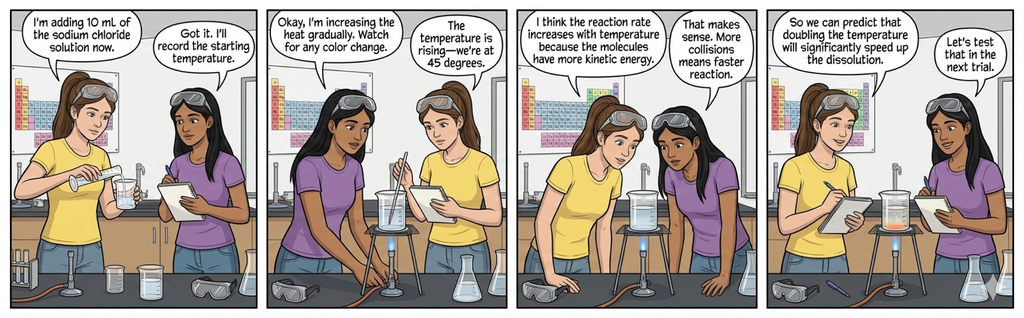

**Key Feature**

**Same-gender control**: Sofia and Priya (two girls) with equal participation. Tests whether **cross-gender contact** is necessary. *Shown to female participants.*

## Mixed-Gender, Unequal: Boy Leads

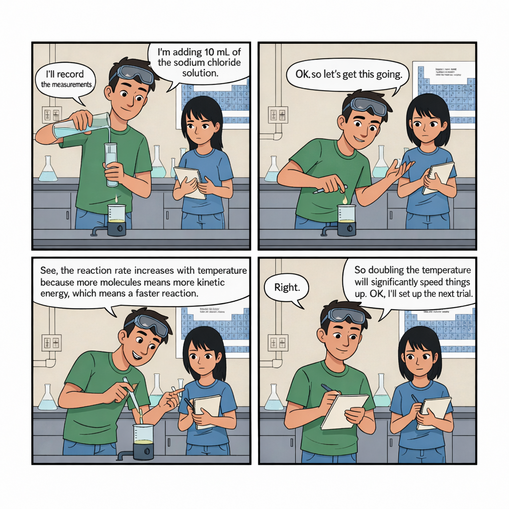

**Key Feature**

**Status manipulation**: Alex leads confidently while Maya responds passively (“Okay,” “Mm-hmm,” “Right”). Tests whether **equal status** is necessary for stereotype reduction.

## Mixed-Gender, Unequal: Girl Leads

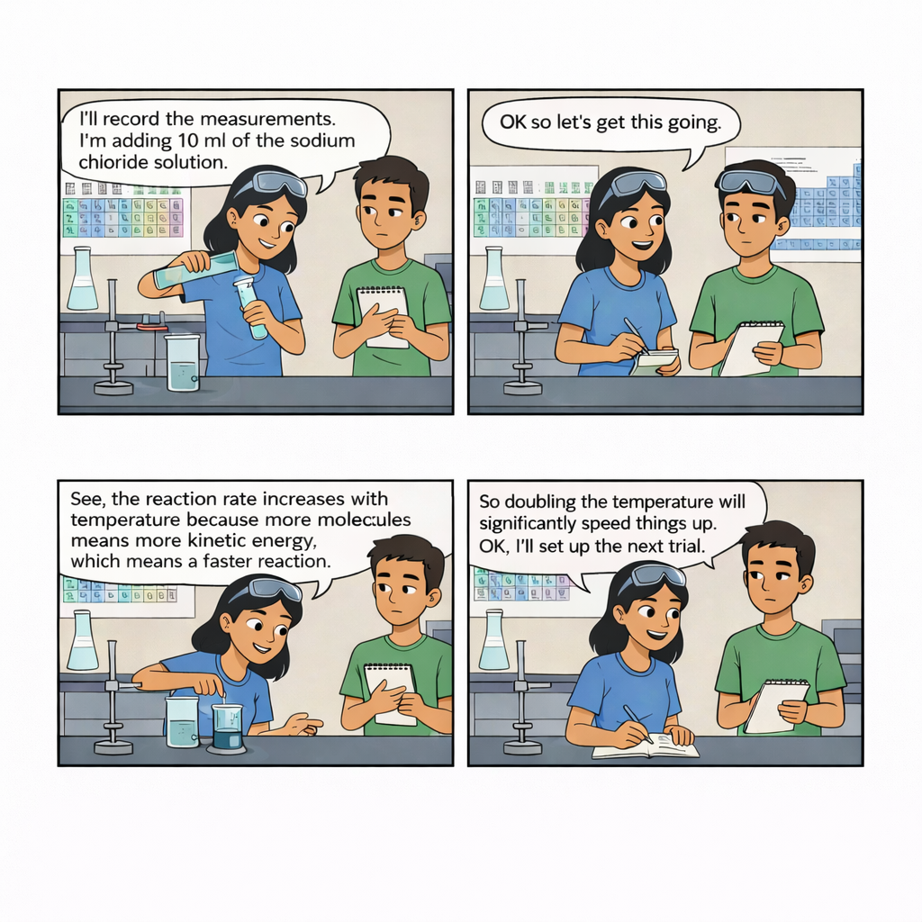

**Key Feature**

**Status manipulation**: Maya leads confidently while Alex responds passively. Counterbalanced to control for gender of leader.

## Solo Learning: Male

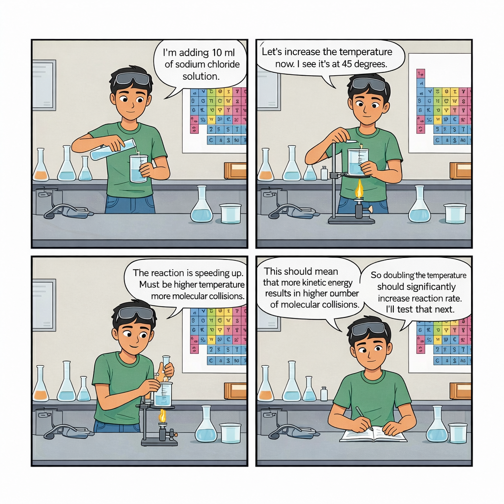

**Key Feature**

**No collaboration**: Alex performs the experiment alone. Tests whether **social interaction** is necessary for effects. *Shown to male participants.*

## Solo Learning: Female

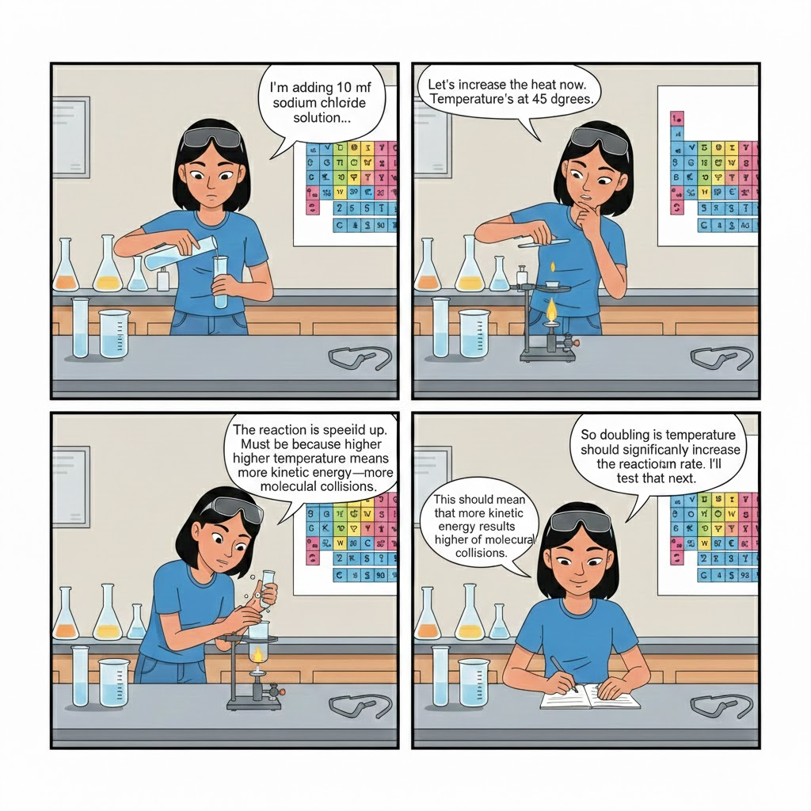

**Key Feature**

**No collaboration**: Maya performs the experiment alone. Same learning content but no social interaction. *Shown to female participants.*

## Measurement Strategy

### Mechanism Measures (Post-Vignette)

**Perceived Norms:**

- *Descriptive:* “Boys and girls both do well in science”
- *Injunctive:* “Teachers approve of girls participating equally”

**Belonging:**

- “People like me belong in science”

**Perceived Equal Status:**

- “Both students had equal say”
- “Both were equally capable”

### Primary Outcomes

- **Stereotype endorsement**

### Secondary Outcomes

- Science interest and enjoyment
- Science self-efficacy
- Behavioral intentions:
  - “Choose a science elective”
  - “Join a science club”
  - “Watch more science content”

## Expected Findings

### Hypotheses

**Bottom Line**

This experiment will provide **causal evidence** for the specific mechanisms underlying stereotype reduction through experiential learning

# Discussion

## Theoretical Contributions

### Marketing Theory: Shared Consumption & Belief Updating

**Science as a “Brand Problem”:**

- “Science is for men” = symbolic branding issue
- Constrains inclusion and market participation
- Identity-linked consumption framework (Chen et al., 2024; Oyserman, 2009)

**Mixed-Gender Experiential Learning as Solution:**

- **Shared consumption** creates opportunities for belief updating
- Students observe counter-stereotypical competence firsthand
- Direct evidence triggers revision of gender-science associations
- Shifts brand from “for boys” → “for us”

**Extension to Marketing**

Shared experiential consumption can trigger **belief updating** that shifts identity associations in stigmatized or exclusionary domains

## Policy Implications

### For NGOs & Policy Makers

- Value proposition extends beyond achievement
- Mobile labs rewrite social scripts
- Scalable to resource-constrained contexts

### For Corporate Funders

- Long-horizon workforce investment
- Co-design mixed-gender experiences
- Present science as collaborative, not competitive

### For School Leaders & Teachers

- Design of everyday group-work matters
- Especially important in larger schools
- Structure equal-status collaboration

## Alignment with UN Sustainable Development Goals

[figure not shown]

### SDG 4: Quality Education

- Improved learning outcomes
- Inquiry-based pedagogy
- Accessible to underserved areas
- Scalable intervention model

### SDG 5: Gender Equality

- Reduced gender stereotypes
- Enhanced sense of belonging
- Inclusive science identity
- Equitable participation

**Relevance**

Demonstrates how educational interventions can **jointly advance learning and equity** worldwide

# Conclusion

## Main Findings Summary

**Learning Outcomes**

↑ **14 pp gain** in science knowledge  
✓ Consistent across all genders  
✓ Robust to matching procedures  
↑ Improved attitudes across 12/14 dimensions

**Attitudinal Outcomes**

↓ **20% reduction** in gender stereotypes  
↑ Stronger effects for boys  
↑ Slightly Amplified in larger schools  
✓ Scalable across diverse classes

**Bottom Line**

Mixed-gender experiential learning operates as both a **pedagogical intervention** and a **social process** that triggers **belief updating** through shared consumption.

Making science feel like it’s “for people like me” requires not just supporting girls’ identities, but also reshaping boys’ perceptions through direct observation of cross-gender competence

## Thank You

Questions & Comments?

Shrihari (Hari) Sridhar

Joe B Foster ’56 Chair in Business Leadership

Senior Associate Dean

Mays Business School | Texas A&M University

ssridhar@mays.tamu.edu

# Appendix

## Moderation by School Size

### Regression Results

| Parameter | Science Knowledge Score |  | Gender-Stereotype Attitudes |  |
| --- | --- | --- | --- | --- |
|  | Coef. (S.E.) | p-value | Coef. (S.E.) | p-value |
| **Treatment × Post × School Size** | -0.009 (0.014) | .50 | **-0.002 (0.001)** | **.011** |
| Treatment × Post | 12.981 (3.289) | <.001 | -0.781 (0.205) | <.001 |
| Post × School Size | 0.006 (0.013) | .636 | 0.002 (0.001) | .032 |
| Post | -0.025 (3.115) | .99 | 0.125 (0.188) | .51 |
| **N** | 10,368 |  | 10,150 |  |
| **R²** | .379 |  | .239 |  |

*Fixed Effects: School × Grade; Standard errors clustered at school level* *School size mean-centered and winsorized at 99th percentile*

**Knowledge**

**p = .50**

NOT significant

Learning gains consistent across school sizes

**Stereotypes**

**p = .011**

Statistically significant

**But:** Effect is small (coef = -0.002)

Larger schools show *modestly* stronger stereotype reduction

## Why Do Larger Schools Show Modestly Stronger Effects?

### The Pattern (Small but Significant)

**Statistically detectable, substantively modest**

### Possible Explanation

**Organizational sorting hypothesis:**

- Larger schools have **more salient gendered norms** (greater gender segregation in peer groups)
- **Structured contact becomes relatively more valuable** (MSL provides rare cross-gender collaboration)
- Consistent with organizational theory (Blau, 1970)

**Interpretation**

School context **slightly** moderates effects, but the intervention works well across all school sizes

## No Moderation by Class Characteristics

**Class Size**

- Knowledge: β = 0.42, p = .15
- Stereotypes: β = -0.00, p = .997

✓ Scalable across classroom sizes

**Proportion of Girls**

- Knowledge: β = -1.96, p = .90
- Stereotypes: β = 0.67, p = .49

✓ Works in diverse compositions

**Practical Implication**

Program effective regardless of classroom structure or gender composition